# Relatório de Análises Estatísticas da Educação Básica no Brasil

### Karina Silva, Luís Fernando Moreira e Renata Richter

### 2017-12-06

[figure not shown]

**1.Introdução**  
De acordo com a Lei de Diretrizes e Bases da Educação de 1996, educação básica compreende a educação infantil, o ensino fundamental e o ensino médio. Essa tem por finalidade promover a “formação comum indispensável para o exercício da cidadania”, além de fornecer meios de prosseguir nos estudos e/ou trabalho. Busca-se por meio deste relatório, em um primeiro momento, comprovar a importância da educação básica a partir do impacto que causa nos Estados e na sociedade como um todo, indo de frente com o tratamento negligente com que a atual gestão vem tratando o tema. Ainda pretende-se identificar as variáveis que afetam a qualidade de tal educação no Brasil, analisando a eficácia das políticas públicas relativas à educação e o impacto da PEC, a qual congela por vinte anos gastos em educação e saúde.  
**2.Objetivos**  
2.1 Analisar o impacto da educação básica no Brasil através das hipóteses a seguir:

[figure not shown]

  Em um primeiro instante, as hipóteses serão analisadas através de gráficos e estatísticas. Visto que os questionamentos presentes neste relatório giram ao entorno de variáveis quantitativas, o gráfico que será usado será o diagrama de dispersão. Por meio dele e de sua linha de quadrados mínimos será possível identificar se há ou não correlação entre as variáveis e se estas mesmas apresentam correlação positiva ou negativa. Buscando ainda mais informações, foram adicionados ao gráfico boxplots marginais que permitem vizualizar os quartis e medianas de cada variável.  
  Pelos mesmos motivos que levaram à escolha do diagrama de dispersão como gráfico a ser utilizado, a estatística adotada é a matriz de correlação. Essa estatística fornece o coeficiente de correlação que varia de -1 (indica relacionamento negativo) a 1 (indica relacionamento positivo).  
  Posteriormente, uma vez que gráficos e estatísticas abrem espaço para interpretações subjetivas, também serão realizados testes de hipóteses. Esses permitirão um estudo mais eficiente e objetivo. No entanto, para a realização de tais testes é necessário verificar se cada variável apresenta ou não uma distribuição normal de informações. Para que isso seja possível serão feitos, por meio do programa R, testes de normalidade. Seus critérios serão:  
  H0: a distribuição é normal  
  H1: a distribuição não é normal  
  alfa=0,05  
  p-valor menor ou igual a alfa => rejeita-se H0  
  p-valor > alfa => não se rejeita H0  
  Caso todas as variáveis apresentem distribuição normal, o teste de hipótese a ser aplicado será o de Correlação de Pearson. Este é o melhor teste que pode ser utilizado, entretanto, durante seu cálculo, pressupõe distribuição normal, por isso a restrição para usá-lo. Caso ao menos uma das variáveis não possua distribuição normal, o teste a ser aplicado será o de Correlação de Spearman.Critérios para ambos os testes de correlação:  
  H0: p=0 => são independentes (não há correlação)  
  H1: p diferente de 0 => não são independentes  
  alfa=0,05  
  p-valor menor ou igual a alfa => rejeita-se H0  
  p-valor > alfa => não se rejeito H0

**4.Análise**

4.1 Impacto da educação  
1ª hipótese: “Estados com maior gasto em educação têm maior qualidade de vida.”

Gráfico

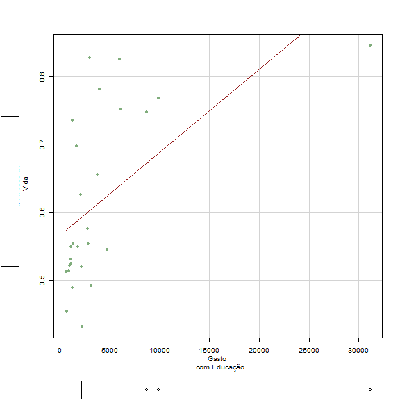

```r
> scatterplot(Qualidade.de.Vida~Gasto.com.Educação, reg.line=lm, smooth=FALSE,
+   spread=FALSE, boxplots='xy', span=0.5, ellipse=FALSE, levels=c(.5, .9),
+   xlab="Gasto
+   com Educação", ylab="Qualidade de
+   Vida", data=educ, pch=19, col=c("#961f1f",1,"#80ad7c"))
```

Nesse gráfico, relacionam-se as variáveis qualidade de vida e gasto com educação. Nele é possível perceber pela inclinação da linha de quadrados mínimos a relação positiva forte entre as variáveis, ou seja, quanto maior os gastos em educação em um Estado, maior tende a ser sua qualidade de vida. Apesar dessa correlação expressiva, observa-se, através dos boxplots, que os gastos em educação ainda são poucos para sua relevância; tendo como quarto quartil gastos de até pouco mais de 5 milhões. Uma exceção de destaque é o outlier que chega a gastar mais de 30 milhões em educação. Com relação ao boxplot de qualidade de vida, as informações de 50 a 100%, isto é, a partir da mediana, apresentam-se bem espalhadas; o que, provavelmente, deve-se a influência de outros fatores sobre essa variável, os quais não são pertinentes a este estudo em específico.  
Teste de Normalidade

- Gasto com Educação:

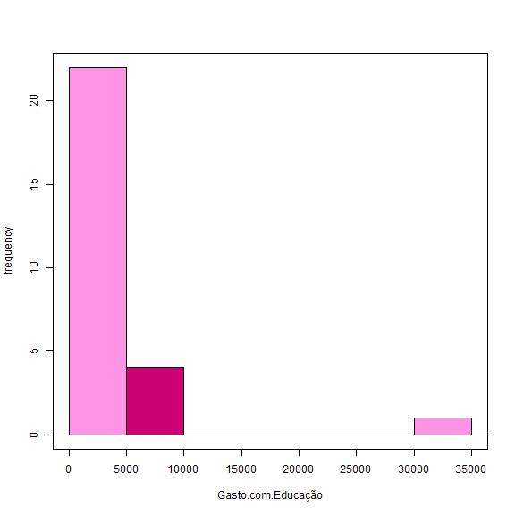

```r
> with(educ, Hist(Gasto.com.Educação, scale="frequency", breaks="Sturges",
+   col=c("#ff93e6","#ce0075")))
```

Com base nesse histograma, pode-se esperar que a variável em questão não possui uma distribuição normal, pois seu formato é diferente do de um sino.

```r
> with(educ, shapiro.test(Gasto.com.Educação))
```

```
    Shapiro-Wilk normality test

data:  Gasto.com.Educação
W = 0.51007, p-value = 2.134e-08
```

H0: a distribuição é normal  
H1: a distribuição não é normal  
alfa=0,05  
p-valor menor ou igual a alfa => rejeita-se H0  
p-valor > alfa => não se rejeita H0  
**=>** Rejeita H0: a distribuição **NÃO** é normal.

- Qualidade de Vida

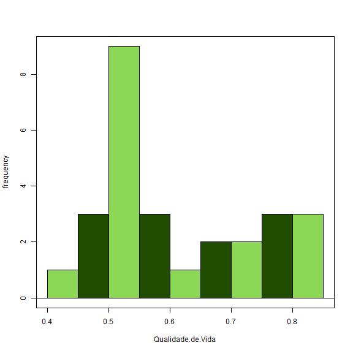

```r
> with(educ, Hist(Qualidade.de.Vida, scale="frequency", breaks="Sturges",
+   col=c("#8cd856","#204c00")))
```

Com base nesse histograma, pode-se esperar que a variável em questão não possui uma distribuição normal, pois seu formato é diferente do de um sino.

```r
> with(educ, shapiro.test(Qualidade.de.Vida))
```

```
    Shapiro-Wilk normality test

data:  Qualidade.de.Vida
W = 0.89032, p-value = 0.00809
```

H0: a distribuição é normal  
H1: a distribuição não é normal  
alfa=0,05  
p-valor menor ou igual a alfa => rejeita-se H0  
p-valor > alfa => não se rejeita H0  
**=>** Rejeita H0: a distribuição **NÃO** é normal.  
Teste de Hipóteses: Teste de Correlação de Spearman

```r
> with(educ, cor.test(Gasto.com.Educação, Qualidade.de.Vida, alternative="two.sided",
+   method="spearman"))
```

```
    Spearman's rank correlation rho

data:  Gasto.com.Educação and Qualidade.de.Vida
S = 1066.3, p-value = 0.0001141
alternative hypothesis: true rho is not equal to 0
sample estimates:
      rho
0.6745038
```

H0: p=0 => são independentes  
H1: p diferente de 0 => há correlação  
alfa=0,05  
p-valor menor ou igual a alfa => rejeita-se H0  
p-valor > alfa => não se rejeito H0  
**=>** Rejeita H0: 1ª hipótese confirmada! De fato Estados com maior gasto em educação têm maior qualidade de vida.  
2ª hipótese: “Estados com maior média de anos de estudo possuem maior renda per capita.”  
Gráfico

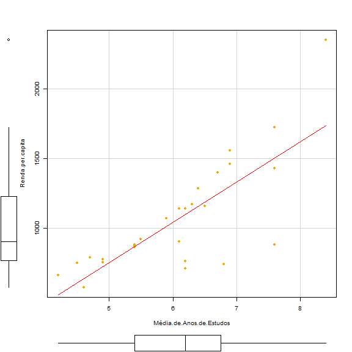

```r
> scatterplot(Renda.per.capita~Média.de.Anos.de.Estudos, reg.line=lm, smooth=FALSE,
+   spread=FALSE, boxplots='xy', span=0.5, ellipse=FALSE, levels=c(.5, .9), data=educ,
+   pch=19, col=c("red",1,"#efab00"))
```

A partir da linha de quadrados mínimos, observa-se que há uma correlação positiva mediana entre as variáveis. Isto é, quanto maior a média de anos de estudos de um indivíduo, maior tende a ser sua renda per capita. Ainda percebe-se que a mediana da média de anos de estudos está por volta de 6,2 anos - tempo este que somente seria suficiente para a conclusão do primeiro segmento do ensino fundamental.E o fato do terceiro quartil dessa mesma variável encontrar-se ainda abaixo dos 7 anos, explica 75% dos Estados apresentarem renda per capita abaixo de dois salários mínimos (que em 2016 era R$880,00), visto que essas variáveis se correlacionam.  
Teste de Normalidade

- Média de Anos de Estudos

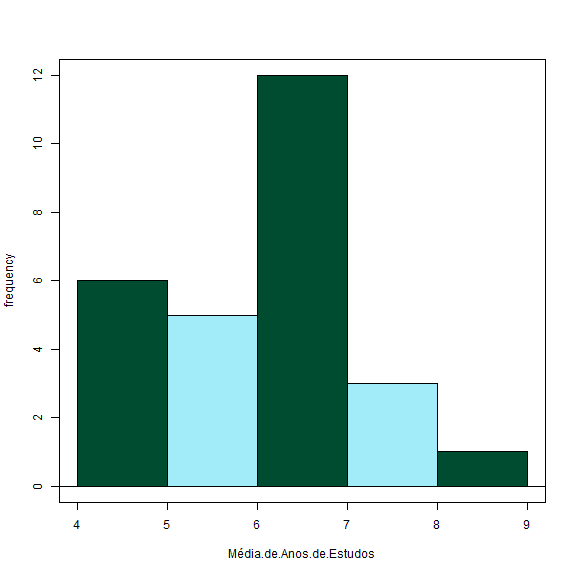

```r
> with(educ, Hist(Média.de.Anos.de.Estudos, scale="frequency", breaks="Sturges",
+   col=c("#004c30","#a2ecf9")))
```

Com base nesse histograma, pode-se esperar que a variável em questão possua uma distribuição normal, pois seu formato assemelha-se ao de um sino.

```r
> with(educ, shapiro.test(Média.de.Anos.de.Estudos))
```

```
    Shapiro-Wilk normality test

data:  Média.de.Anos.de.Estudos
W = 0.97362, p-value = 0.6991
```

H0: a distribuição é normal  
H1: a distribuição não é normal  
alfa=0,05  
p-valor menor ou igual a alfa => rejeita-se H0  
p-valor > alfa => não se rejeita H0  
**=>** Não rejeita H0: a distribuição **É** normal.

- Renda per capita

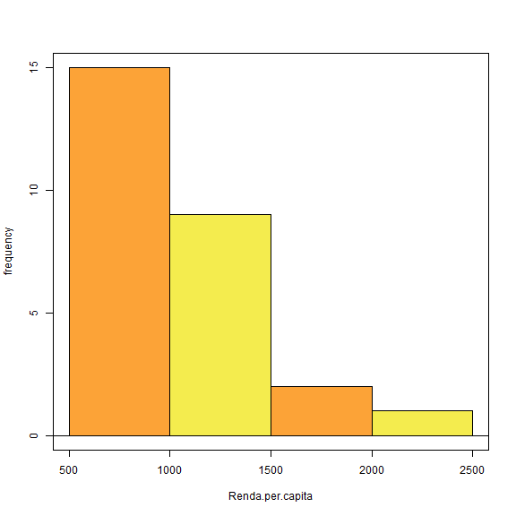

```r
> with(educ, Hist(Renda.per.capita, scale="frequency", breaks="Sturges",
+   col=c("#fca337","#f4ec4e")))
```

Com base nesse histograma, pode-se esperar que a variável em questão não possui uma distribuição normal, pois seu formato é diferente do de um sino.

```r
> with(educ, shapiro.test(Renda.per.capita))
```

```
    Shapiro-Wilk normality test

data:  Renda.per.capita
W = 0.86656, p-value = 0.002495
```

H0: a distribuição é normal  
H1: a distribuição não é normal  
alfa=0,05  
p-valor menor ou igual a alfa => rejeita-se H0  
p-valor > alfa => não se rejeita H0  
**=>** Rejeita H0: a distribuição **NÃO** é normal.  
Teste de Hipóteses: Teste de Correlação de Spearman

```r
> with(educ, cor.test(Média.de.Anos.de.Estudos, Renda.per.capita,
+   alternative="two.sided", method="spearman"))
```

```
    Spearman's rank correlation rho

data:  Média.de.Anos.de.Estudos and Renda.per.capita
S = 834.4, p-value = 8.184e-06
alternative hypothesis: true rho is not equal to 0
sample estimates:
     rho
0.745298
```

H0: p=0 => são independentes  
H1: p diferente de 0 => há correlação  
alfa=0,05  
p-valor menor ou igual a alfa => rejeita-se H0  
p-valor > alfa => não se rejeito H0  
**=>** Rejeita H0: 2ª hipótese confirmada! De fato Estados com maior média de anos de estudo possuem maior renda per capita.  
3ª hipótese: “Estados com notas maiores no ideb possuem menor taxa de criminalidade.”  
Gráfico

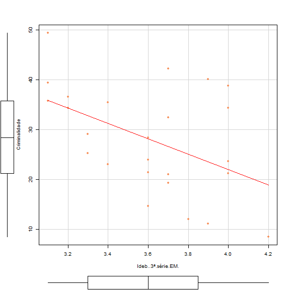

```r
> scatterplot(Criminalidade~Ideb..3ª.série.EM., reg.line=lm, smooth=FALSE,
+   spread=FALSE, boxplots='xy', span=0.5, ellipse=FALSE, levels=c(.5, .9), data=educ,
+   pch=19, col=c("red",1,"#f79460"))
```

- Ideb

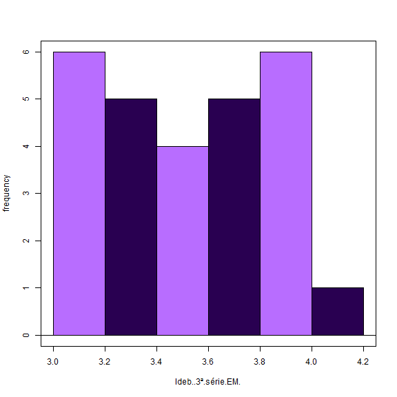

```r
> with(educ, Hist(Ideb..3ª.série.EM., scale="frequency", breaks="Sturges",
+   col=c("#b86dff","#290051")))
```

Com base nesse histograma, pode-se esperar que a variável em questão não possui uma distribuição normal, pois seu formato é diferente do de um sino.

```r
> with(educ, shapiro.test(Ideb..3ª.série.EM.))
```

```
    Shapiro-Wilk normality test

data:  Ideb..3ª.série.EM.
W = 0.94158, p-value = 0.1333
```

H0: a distribuição é normal  
H1: a distribuição não é normal  
alfa=0,05  
p-valor menor ou igual a alfa => rejeita-se H0  
p-valor > alfa => não se rejeita H0  
**=>** Não rejeita H0: a distribuição **É** normal.

- Criminalidade

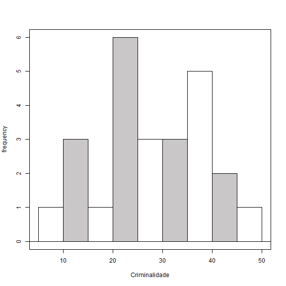

```r
> with(educ, Hist(Criminalidade, scale="frequency", breaks="Sturges", col=c("#ffffff","#c9c7c7")))
```

Com base nesse histograma, pode-se esperar que a variável em questão possua uma distribuição normal, pois seu formato assemelha-se ao de um sino.

```r
> with(educ, shapiro.test(Criminalidade))
```

```
    Shapiro-Wilk normality test

data:  Criminalidade
W = 0.97406, p-value = 0.7483
```

H0: a distribuição é normal  
H1: a distribuição não é normal  
alfa=0,05  
p-valor menor ou igual a alfa => rejeita-se H0  
p-valor > alfa => não se rejeita H0  
**=>** Não rejeita H0: a distribuição **É** normal.  
Teste de Hipóteses: Teste de Correlação de Pearson

```r
> with(educ, cor.test(Criminalidade, Ideb..3ª.série.EM., alternative="two.sided",
+   method="pearson"))
```

```
    Pearson's product-moment correlation

data:  Criminalidade and Ideb..3ª.série.EM.
t = -2.5836, df = 23, p-value = 0.01661
alternative hypothesis: true correlation is not equal to 0
95 percent confidence interval:
 -0.73219374 -0.09739886
sample estimates:
       cor
-0.4742771
```

H0: p=0 => são independentes  
H1: p diferente de 0 => há correlação  
alfa=0,05  
p-valor menor ou igual a alfa => rejeita-se H0  
p-valor > alfa => não se rejeito H0  
**=>** Rejeita H0: 3ªhipótese confirmada! De fato Estados com maiores no ideb possuem menor taxa de criminalidade.  
**4.2 Variáveis que afetam a qualidade da educação básica no Brasil**  
1ª hipótese: “Estados que gastam mais com educação possuem melhores oportunidades educacionais e menor taxa de evasão no Ensino Médio.”  
Estatística

```r
> require(corrplot)
```

```r
> M <- cor(educ[,c("Gasto.com.Educação","IOEB","Taxa.de.Evasão.do.EM")])
```

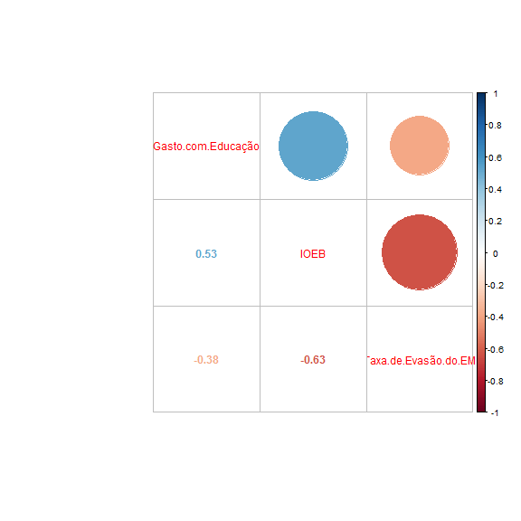

```r
> corrplot.mixed(M)
```

- Gasto com Educação

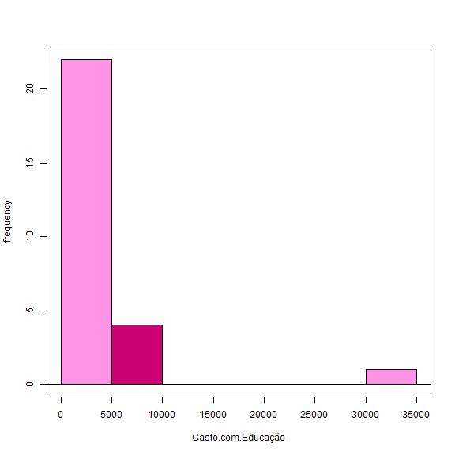

```r
> with(educ, Hist(Gasto.com.Educação, scale="frequency", breaks="Sturges",
+   col=c("#ff93e6","#ce0075")))
```

Com base nesse histograma, pode-se esperar que a variável em questão não possui uma distribuição normal, pois seu formato é diferente do de um sino.

```r
> with(educ, shapiro.test(Gasto.com.Educação))
```

```
    Shapiro-Wilk normality test

data:  Gasto.com.Educação
W = 0.51007, p-value = 2.134e-08
```

H0: a distribuição é normal  
H1: a distribuição não é normal  
alfa=0,05  
p-valor menor ou igual a alfa => rejeita-se H0  
p-valor > alfa => não se rejeita H0  
**=>** Rejeita H0: a distribuição **NÃO** é normal.

- IOEB

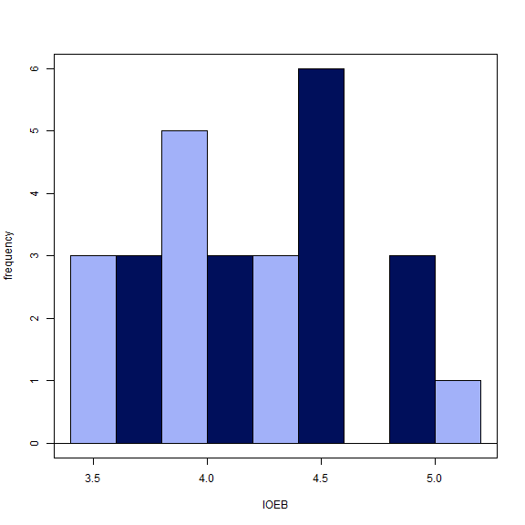

```r
> with(educ, Hist(IOEB, scale="frequency", breaks="Sturges", col=c("#a2b1f9","#000f5b")))
```

Com base nesse histograma, pode-se esperar que a variável em questão possua uma distribuição normal, pois seu formato assemelha-se ao de um sino.

```r
> with(educ, shapiro.test(IOEB))
```

```
    Shapiro-Wilk normality test

data:  IOEB
W = 0.9551, p-value = 0.2842
```

H0: a distribuição é normal  
H1: a distribuição não é normal  
alfa=0,05  
p-valor menor ou igual a alfa => rejeita-se H0  
p-valor > alfa => não se rejeita H0  
**=>** Não rejeita H0: a distribuição **É** normal.

- Taxa de Evasão do EM

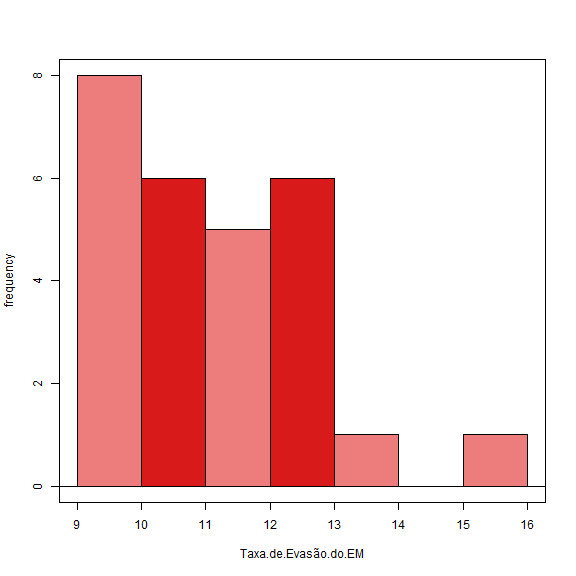

```r
> with(educ, Hist(Taxa.de.Evasão.do.EM, scale="frequency", breaks="Sturges",
+   col=c("#ed7d7d","#d81a1a")))
```

```r
> with(educ, shapiro.test(Taxa.de.Evasão.do.EM))
```

```
    Shapiro-Wilk normality test

data:  Taxa.de.Evasão.do.EM
W = 0.93913, p-value = 0.1159
```

H0: a distribuição é normal  
H1: a distribuição não é normal  
alfa=0,05  
p-valor menor ou igual a alfa => rejeita-se H0  
p-valor > alfa => não se rejeita H0  
**=>** Não rejeita H0: a distribuição **É** normal.  
Teste de Hipóteses: Teste de Correlação de Spearman

```r
> with(educ, cor.test(Gasto.com.Educação, IOEB, alternative="two.sided",
+   method="spearman"))
```

```
    Spearman's rank correlation rho

data:  Gasto.com.Educação and IOEB
S = 1678.9, p-value = 0.009896
alternative hypothesis: true rho is not equal to 0
sample estimates:
      rho
0.4875236
```

H0: p=0 => são independentes  
H1: p diferente de 0 => há correlação  
alfa=0,05  
p-valor menor ou igual a alfa => rejeita-se H0  
p-valor > alfa => não se rejeito H0  
**=>** Rejeita H0

```r
> with(educ, cor.test(Gasto.com.Educação, Taxa.de.Evasão.do.EM,
+   alternative="two.sided", method="spearman"))
```

```
    Spearman's rank correlation rho

data:  Gasto.com.Educação and Taxa.de.Evasão.do.EM
S = 3917.3, p-value = 0.3278
alternative hypothesis: true rho is not equal to 0
sample estimates:
       rho
-0.1957436
```

**=>** Não rejeita H0: as variáveis são independentes.

```r
> with(educ, cor.test(IOEB, Taxa.de.Evasão.do.EM, alternative="two.sided",
+   method="spearman"))
```

```
    Spearman's rank correlation rho

data:  IOEB and Taxa.de.Evasão.do.EM
S = 5338.7, p-value = 0.0004331
alternative hypothesis: true rho is not equal to 0
sample estimates:
       rho
-0.6296438
```

**=>** Rejeita H0  
**=>** 1ª hipótese parcialmente confirmada: há correlação entre gasto com educação e IOEB, mas não há correlação entre gato com educação e taxa de evasão no ensino médio. Também confirmada a correlação entre IOEB e taxa de evasão.  
2ª hipótese: “Estados com mais escolas têm maior ideb.”  
Gráfico

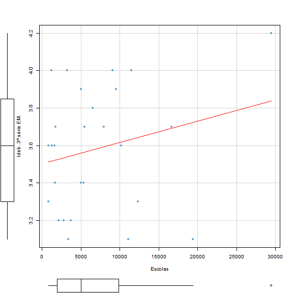

```r
> scatterplot(Ideb..3ª.série.EM.~Escolas, reg.line=lm, smooth=FALSE, spread=FALSE,
+   boxplots='xy', span=0.5, ellipse=FALSE, levels=c(.5, .9), data=educ, pch=19,
+   col=c("red",1,"#609dc4"))
```

A partir desse diagrama de dispersão, a relação entre o número de escolas com o ideb aparenta existir, apesar de fraquíssima, ou seja, o aumento de escolas acarretaria no aumento da nota do ideb. Porém, tendo em vista que os pontos do diagrama apresentam-se muito dispersos, é provável que ao realizar o teste de hipótese correspondente a essas variáveis, a correlação seja rejeitada.  
Teste de Normalidade

- Escolas

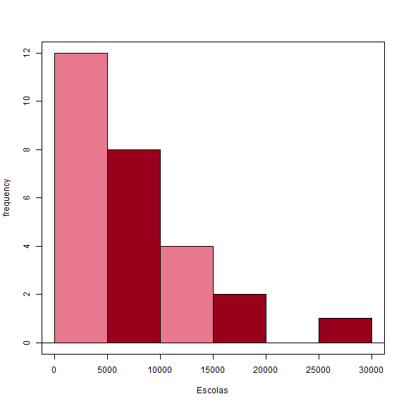

```r
> with(educ, Hist(Escolas, scale="frequency", breaks="Sturges", col=c("#e8788d","#99001c")))
```

Com base nesse histograma, pode-se esperar que a variável em questão não possui uma distribuição normal, pois seu formato é diferente do de um sino.

```r
> with(educ, shapiro.test(Escolas))
```

```
    Shapiro-Wilk normality test

data:  Escolas
W = 0.81936, p-value = 0.0003019
```

H0: a distribuição é normal  
H1: a distribuição não é normal  
alfa=0,05  
p-valor menor ou igual a alfa => rejeita-se H0  
p-valor > alfa => não se rejeita H0  
**=>** Rejeita H0: a distribuição **NÃO** é normal.

- Ideb

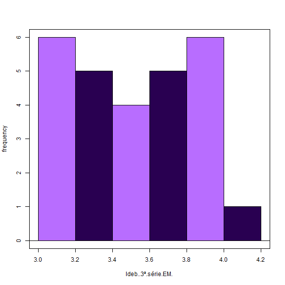

```r
> with(educ, Hist(Ideb..3ª.série.EM., scale="frequency", breaks="Sturges",
+   col=c("#b86dff","#290051")))
```

Com base nesse histograma, pode-se esperar que a variável em questão não possui uma distribuição normal, pois seu formato é diferente do de um sino.

```r
> with(educ, shapiro.test(Ideb..3ª.série.EM.))
```

```
    Shapiro-Wilk normality test

data:  Ideb..3ª.série.EM.
W = 0.94158, p-value = 0.1333
```

H0: a distribuição é normal  
H1: a distribuição não é normal  
alfa=0,05  
p-valor menor ou igual a alfa => rejeita-se H0  
p-valor > alfa => não se rejeita H0  
**=>** Não rejeita H0: a distribuição **É** normal.  
Teste de Hipóteses: Teste de Correlação de Spearman

```r
> with(educ, cor.test(Escolas, Ideb..3ª.série.EM., alternative="two.sided",
+   method="spearman"))
```

```
    Spearman's rank correlation rho

data:  Escolas and Ideb..3ª.série.EM.
S = 2842.1, p-value = 0.5102
alternative hypothesis: true rho is not equal to 0
sample estimates:
      rho
0.1324554
```

H0: p=0 => são independentes  
H1: p diferente de 0 => há correlação  
alfa=0,05  
p-valor menor ou igual a alfa => rejeita-se H0  
p-valor > alfa => não se rejeito H0  
**=>** Não rejeita H0: 2ª hipóstese rejeitada! O número de escolas em um Estado não influência na sua nota no ideb.  
3ª hipótese: “Estados com maior ioeb possuem maior média de anos de estudos.”  
Gráfico

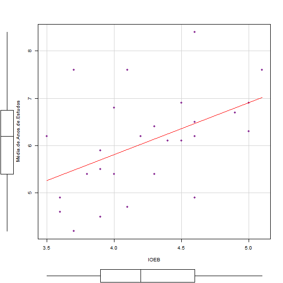

```r
> scatterplot(Média.de.Anos.de.Estudos~IOEB, reg.line=lm, smooth=FALSE, spread=FALSE,
+   boxplots='xy', span=0.5, ellipse=FALSE, levels=c(.5, .9), data=educ,pch=19,
+   col=c("red",1,"#91399b"))
```

Nesse gráfico, relaciona-se a média de anos de estudos com o ioeb, e é possível concluir que uma interfere na outra de maneira positiva. No entanto, essa relação é fraca, visto que a inclinação da linha de quadrados mínimos não é tão expressiva. Entretanto, ainda se pode dizer que a mediana da média de anos de estudos ser baixa é pela correlação com a baixa mediana do ioeb (cerca de 4,2), sendo assim, tal relação ainda é interessante ao pensar-se em uma política pública acerca da educação básica.  
Teste de Normalidade

- IOEB

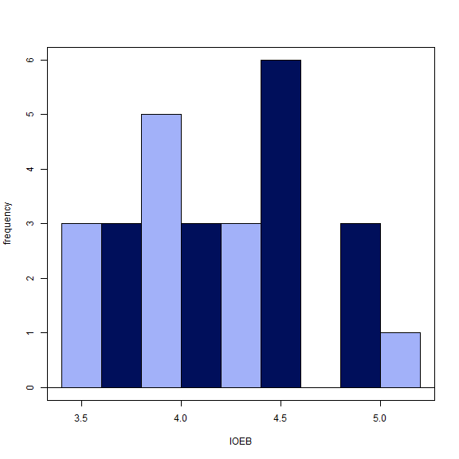

```r
> with(educ, Hist(IOEB, scale="frequency", breaks="Sturges", col=c("#a2b1f9","#000f5b")))
```

Com base nesse histograma, pode-se esperar que a variável em questão possua uma distribuição normal, pois seu formato assemelha-se ao de um sino.

```r
> with(educ, shapiro.test(IOEB))
```

```
    Shapiro-Wilk normality test

data:  IOEB
W = 0.9551, p-value = 0.2842
```

H0: a distribuição é normal  
H1: a distribuição não é normal  
alfa=0,05  
p-valor menor ou igual a alfa => rejeita-se H0  
p-valor > alfa => não se rejeita H0  
**=>** Não rejeita H0: a distribuição **É** normal.

- Média de Anos de Estudos

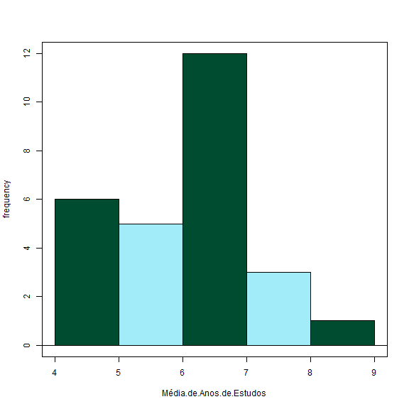

```r
> with(educ, Hist(Média.de.Anos.de.Estudos, scale="frequency", breaks="Sturges",
+   col=c("#004c30","#a2ecf9")))
```

Com base nesse histograma, pode-se esperar que a variável em questão possua uma distribuição normal, pois seu formato assemelha-se ao de um sino.

```r
> with(educ, shapiro.test(Média.de.Anos.de.Estudos))
```

```
    Shapiro-Wilk normality test

data:  Média.de.Anos.de.Estudos
W = 0.97362, p-value = 0.6991
```

H0: a distribuição é normal  
H1: a distribuição não é normal  
alfa=0,05  
p-valor menor ou igual a alfa => rejeita-se H0  
p-valor > alfa => não se rejeita H0  
**=>** Não rejeita H0: a distribuição **É** normal.  
Teste de Hipóteses: Teste de Correlação de Pearson

```r
> with(educ, cor.test(IOEB, Média.de.Anos.de.Estudos, alternative="two.sided",
+   method="pearson"))
```

```
    Pearson's product-moment correlation

data:  IOEB and Média.de.Anos.de.Estudos
t = 2.7161, df = 25, p-value = 0.01181
alternative hypothesis: true correlation is not equal to 0
95 percent confidence interval:
 0.1188844 0.7257087
sample estimates:
      cor
0.4773335
```